# hw2-1

# 各區犯罪次數(103年)

能看出最高犯罪次數皆為:**中壢**(綠色)、**桃園**(天藍)

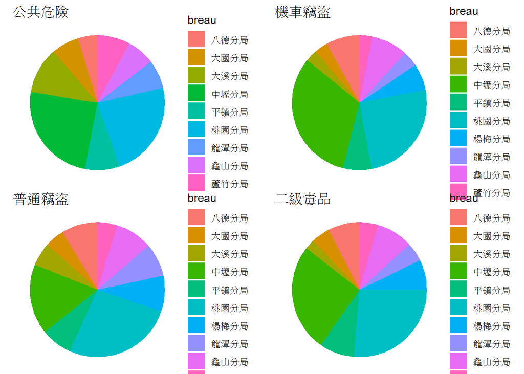

```r
CCCrime <- CCrime[62:70,]
pie <- ggplot(data=CCCrime) +
    geom_bar(aes(x=factor(1),y=h_count,fill=breau),stat = "identity") +
    coord_polar("y", start=0)+
    labs(title="公共危險")
pie1 <- pie + theme_void()

CCCrime <- CCrime[1:10,]
pie <- ggplot(data=CCCrime) +
    geom_bar(aes(x=factor(1),y=h_count,fill=breau),stat = "identity") +
    coord_polar("y", start=0)+
    labs(title="普通竊盜")
pie2 <-pie + theme_void()

CCCrime <- CCrime[20:29,]
pie <- ggplot(data=CCCrime) +
    geom_bar(aes(x=factor(1),y=h_count,fill=breau),stat = "identity") +
    coord_polar("y", start=0)+
    labs(title="機車竊盜")
pie3 <-pie + theme_void()

CCCrime <- CCrime[47:56,]
pie <- ggplot(data=CCCrime) +
    geom_bar(aes(x=factor(1),y=h_count,fill=breau),stat = "identity") +
    coord_polar("y", start=0)+
    labs(title="二級毒品")
pie4 <-pie + theme_void()
multiplot(pie1, pie2, pie3, pie4,cols=2)
```

# 犯罪率與人口密度之間的關係

上張圖得出最高犯罪數為:**中壢**、**桃園**，因此我們來探討**中壢**、**桃園**之犯罪率與人口密度之間的關係

*註：１.犯罪率＝犯罪總數／總人口 2.此犯罪率有乘以倍數，為了使桃園人口密度＝桃園犯罪率，便於看出中壢之差異性*

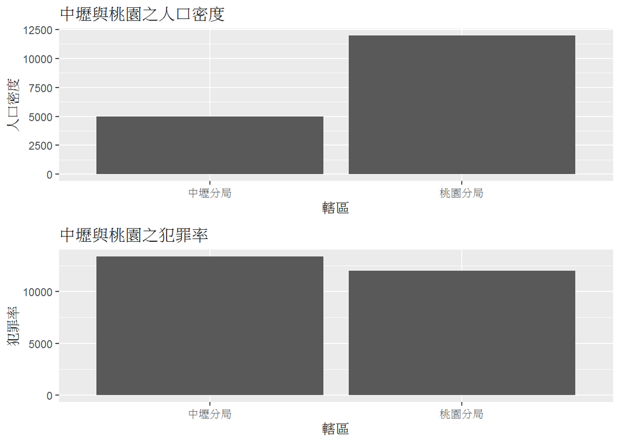

```r
p1 <- ggplot(data=combine2)+
  geom_bar(mapping = aes(x = breau, y = density), stat = "identity")+
    labs(title="中壢與桃園之人口密度",
         x="轄區",
         y="人口密度")
p2 <- ggplot(data=combine2)+
  geom_bar(mapping = aes(x = breau, y = h_r*390404.811073), stat = "identity")+
    labs(title="中壢與桃園之犯罪率",
         x="轄區",
         y="犯罪率")

multiplot(p1, p2, cols=1)
```

# **小節**

經過犯罪人數與總人數的相關統計資訊，令人好奇是否人口成長與犯罪成長存在著正相關關係，若對此有興趣請參考[hw2-2](https://tliobnih.github.io/2019-7-8/Week2/22.html)